# Logistic_Regression

```python
import numpy as np
import pandas as pd
import seaborn as sb
import matplotlib.pyplot as plt
import sklearn
import plotly.express as px

from pandas import Series, DataFrame
from pylab import rcParams
from sklearn import preprocessing

from sklearn.linear_model import LogisticRegression
from sklearn.model_selection import train_test_split
from sklearn.model_selection import cross_val_predict
from sklearn.preprocessing import LabelEncoder, OneHotEncoder
from sklearn.compose import make_column_transformer
from sklearn.pipeline import make_pipeline
```

```python
%matplotlib inline
rcParams['figure.figsize'] = 5,4
sb.set_style('whitegrid')
```

```python
titanic_training = pd.read_csv('titanic-training-data.csv')
titanic_training.head(10)
```

|  | PassengerId | Survived | Pclass | Name | Sex | Age | SibSp | Parch | Ticket | Fare | Cabin | Embarked |
| --- | --- | --- | --- | --- | --- | --- | --- | --- | --- | --- | --- | --- |
| 0 | 1 | 0 | 3 | Braund, Mr. Owen Harris | male | 22.0 | 1 | 0 | A/5 21171 | 7.2500 | NaN | S |
| 1 | 2 | 1 | 1 | Cumings, Mrs. John Bradley (Florence Briggs Th... | female | 38.0 | 1 | 0 | PC 17599 | 71.2833 | C85 | C |
| 2 | 3 | 1 | 3 | Heikkinen, Miss. Laina | female | 26.0 | 0 | 0 | STON/O2. 3101282 | 7.9250 | NaN | S |
| 3 | 4 | 1 | 1 | Futrelle, Mrs. Jacques Heath (Lily May Peel) | female | 35.0 | 1 | 0 | 113803 | 53.1000 | C123 | S |
| 4 | 5 | 0 | 3 | Allen, Mr. William Henry | male | 35.0 | 0 | 0 | 373450 | 8.0500 | NaN | S |
| 5 | 6 | 0 | 3 | Moran, Mr. James | male | NaN | 0 | 0 | 330877 | 8.4583 | NaN | Q |
| 6 | 7 | 0 | 1 | McCarthy, Mr. Timothy J | male | 54.0 | 0 | 0 | 17463 | 51.8625 | E46 | S |
| 7 | 8 | 0 | 3 | Palsson, Master. Gosta Leonard | male | 2.0 | 3 | 1 | 349909 | 21.0750 | NaN | S |
| 8 | 9 | 1 | 3 | Johnson, Mrs. Oscar W (Elisabeth Vilhelmina Berg) | female | 27.0 | 0 | 2 | 347742 | 11.1333 | NaN | S |
| 9 | 10 | 1 | 2 | Nasser, Mrs. Nicholas (Adele Achem) | female | 14.0 | 1 | 0 | 237736 | 30.0708 | NaN | C |

### DATASET DESCRIPTIONS

Survived - Survival (0 = No; 1 = Yes)  
Pclass - Passenger Class (1 = 1st; 2 = 2nd; 3 = 3rd)  
Name - Name  
Sex - Sex  
Age - Age  
SibSp - Number of Siblings/Spouses Aboard  
Parch - Number of Parents/Children Aboard  
Ticket - Ticket Number  
Fare - Passenger Fare (British pound)  
Cabin - Cabin  
Embarked - Port of Embarkation (C = Cherbourg, France; Q = Queenstown, UK; S = Southampton - Cobh, Ireland)

```python
titanic_training.info()
```

```
<class 'pandas.core.frame.DataFrame'>
RangeIndex: 891 entries, 0 to 890
Data columns (total 12 columns):
 #   Column       Non-Null Count  Dtype
---  ------       --------------  -----
 0   PassengerId  891 non-null    int64
 1   Survived     891 non-null    int64
 2   Pclass       891 non-null    int64
 3   Name         891 non-null    object
 4   Sex          891 non-null    object
 5   Age          714 non-null    float64
 6   SibSp        891 non-null    int64
 7   Parch        891 non-null    int64
 8   Ticket       891 non-null    object
 9   Fare         891 non-null    float64
 10  Cabin        204 non-null    object
 11  Embarked     889 non-null    object
dtypes: float64(2), int64(5), object(5)
memory usage: 83.7+ KB
```

### Checking that your target variable is binary

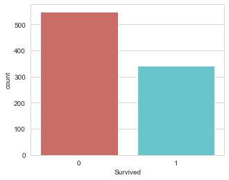

```python
sb.countplot(x = 'Survived', data = titanic_training, palette = 'hls');
```

### Checking for missing values

```python
titanic_training.isnull().sum()
```

```
PassengerId      0
Survived         0
Pclass           0
Name             0
Sex              0
Age            177
SibSp            0
Parch            0
Ticket           0
Fare             0
Cabin          687
Embarked         2
dtype: int64
```

```python
titanic_training.describe()
```

|  | PassengerId | Survived | Pclass | Age | SibSp | Parch | Fare |
| --- | --- | --- | --- | --- | --- | --- | --- |
| count | 891.000000 | 891.000000 | 891.000000 | 714.000000 | 891.000000 | 891.000000 | 891.000000 |
| mean | 446.000000 | 0.383838 | 2.308642 | 29.699118 | 0.523008 | 0.381594 | 32.204208 |
| std | 257.353842 | 0.486592 | 0.836071 | 14.526497 | 1.102743 | 0.806057 | 49.693429 |
| min | 1.000000 | 0.000000 | 1.000000 | 0.420000 | 0.000000 | 0.000000 | 0.000000 |
| 25% | 223.500000 | 0.000000 | 2.000000 | 20.125000 | 0.000000 | 0.000000 | 7.910400 |
| 50% | 446.000000 | 0.000000 | 3.000000 | 28.000000 | 0.000000 | 0.000000 | 14.454200 |
| 75% | 668.500000 | 1.000000 | 3.000000 | 38.000000 | 1.000000 | 0.000000 | 31.000000 |
| max | 891.000000 | 1.000000 | 3.000000 | 80.000000 | 8.000000 | 6.000000 | 512.329200 |

### Taking care of missing values

##### Dropping missing values

So let's just go ahead and drop all the variables that aren't relevant for predicting survival. We should at least keep the following:

- Survived - This variable is obviously relevant.
- Pclass - Does a passenger's class on the boat affect their survivability?
- Sex - Could a passenger's gender impact their survival rate?
- Age - Does a person's age impact their survival rate?
- SibSp - Does the number of relatives on the boat (that are siblings or a spouse) affect a person survivability? Probability
- Parch - Does the number of relatives on the boat (that are children or parents) affect a person survivability? Probability
- Fare - Does the fare a person paid effect his survivability? Maybe - let's keep it.
- Embarked - Does a person's point of embarkation matter? It depends on how the boat was filled... Let's keep it.

What about a person's name, ticket number, and passenger ID number? They're irrelavant for predicting survivability. And as you recall, the cabin variable is almost all missing values, so we can just drop all of these.

```python
titanic_data = titanic_training.drop(['Name', 'Ticket', 'Cabin', 'PassengerId'], axis = 1)
titanic_data.head(7)
```

|  | Survived | Pclass | Sex | Age | SibSp | Parch | Fare | Embarked |
| --- | --- | --- | --- | --- | --- | --- | --- | --- |
| 0 | 0 | 3 | male | 22.0 | 1 | 0 | 7.2500 | S |
| 1 | 1 | 1 | female | 38.0 | 1 | 0 | 71.2833 | C |
| 2 | 1 | 3 | female | 26.0 | 0 | 0 | 7.9250 | S |
| 3 | 1 | 1 | female | 35.0 | 1 | 0 | 53.1000 | S |
| 4 | 0 | 3 | male | 35.0 | 0 | 0 | 8.0500 | S |
| 5 | 0 | 3 | male | NaN | 0 | 0 | 8.4583 | Q |
| 6 | 0 | 1 | male | 54.0 | 0 | 0 | 51.8625 | S |

### Imputing missing values

```python
fig = px.box(titanic_data, x = "Parch", y = "Age")
fig.show();
```

[interactive chart not shown]

```python
parch_groups = titanic_data.groupby(titanic_data['Parch'])
parch_groups.mean()
```

| Parch | Survived | Pclass | Age | SibSp | Fare |
| --- | --- | --- | --- | --- | --- |
| 0 | 0.343658 | 2.321534 | 32.178503 | 0.237463 | 25.586774 |
| 1 | 0.550847 | 2.203390 | 24.422000 | 1.084746 | 46.778180 |
| 2 | 0.500000 | 2.275000 | 17.216912 | 2.062500 | 64.337604 |
| 3 | 0.600000 | 2.600000 | 33.200000 | 1.000000 | 25.951660 |
| 4 | 0.000000 | 2.500000 | 44.500000 | 0.750000 | 84.968750 |
| 5 | 0.200000 | 3.000000 | 39.200000 | 0.600000 | 32.550000 |
| 6 | 0.000000 | 3.000000 | 43.000000 | 1.000000 | 46.900000 |

```python
age_mean = parch_groups.mean()['Age'].round()
age_mean
```

```
Parch
0    32.0
1    24.0
2    17.0
3    33.0
4    44.0
5    39.0
6    43.0
Name: Age, dtype: float64
```

```python
def age_approx(cols, age_mean=age_mean):
    Age = cols[0]
    Parch = cols[1]

    if pd.isnull(Age):
        if Parch == 0:
            return age_mean[0]
        elif Parch == 1:
            return age_mean[1]
        elif Parch == 2:
            return age_mean[2]
        elif Parch == 3:
            return age_mean[3]
        elif Parch == 4:
            return age_mean[4]
        else:
            return (age_mean[5] + age_mean[6])/2
    else:
        return Age
```

```python
titanic_data['Age']= titanic_data[['Age', 'Parch']].apply(age_approx, axis = 1)
titanic_data.isnull().sum()
```

```
Survived    0
Pclass      0
Sex         0
Age         0
SibSp       0
Parch       0
Fare        0
Embarked    2
dtype: int64
```

```python
titanic_data.dropna(inplace = True)
titanic_data.reset_index(inplace = True, drop = True)

titanic_data.info()
```

```
<class 'pandas.core.frame.DataFrame'>
RangeIndex: 889 entries, 0 to 888
Data columns (total 8 columns):
 #   Column    Non-Null Count  Dtype
---  ------    --------------  -----
 0   Survived  889 non-null    int64
 1   Pclass    889 non-null    int64
 2   Sex       889 non-null    object
 3   Age       889 non-null    float64
 4   SibSp     889 non-null    int64
 5   Parch     889 non-null    int64
 6   Fare      889 non-null    float64
 7   Embarked  889 non-null    object
dtypes: float64(2), int64(4), object(2)
memory usage: 55.7+ KB
```

```python
fig = px.imshow(titanic_data.corr(),
#                 color_continuous_midpoint=0,
                color_continuous_scale = 'mint_r',
               title = "Heatmap for correlation")
fig.update_xaxes(side = "top")
fig.show()
```

[interactive chart not shown]

Logistic Regression assumption is that predictant should be intedependent of each other, we noticed **Pclass** & **Fare** has a slight linear dependency on each other. Now we have to remove these columns to fullfil model assumptions. Other model assumtions are listed below

[figure not shown]

```python
titanic_data.drop(["Pclass", "Fare"], axis = 1, inplace = True)
titanic_data.replace({'male': 1, "female": 0}, inplace=True)

X_train = titanic_data.drop(["Survived"], axis = 1)
y_train = titanic_data.Survived
X_train.head()
```

|  | Sex | Age | SibSp | Parch | Embarked |
| --- | --- | --- | --- | --- | --- |
| 0 | 1 | 22.0 | 1 | 0 | S |
| 1 | 0 | 38.0 | 1 | 0 | C |
| 2 | 0 | 26.0 | 0 | 0 | S |
| 3 | 0 | 35.0 | 1 | 0 | S |
| 4 | 1 | 35.0 | 0 | 0 | S |

```python
column_names = X_train.columns.to_list()
column_names
```

```
['Sex', 'Age', 'SibSp', 'Parch', 'Embarked']
```

```python
label_encoder = LabelEncoder()
one_hot_encoder = OneHotEncoder()
lr = LogisticRegression(solver='liblinear')

ct = make_column_transformer(
        (one_hot_encoder, ['Embarked']),
        remainder = 'passthrough'
)

pipeline = make_pipeline(ct, lr)
pipeline.fit(X_train, y_train)
```

```
Pipeline(steps=[('columntransformer',
                 ColumnTransformer(remainder='passthrough',
                                   transformers=[('onehotencoder',
                                                  OneHotEncoder(),
                                                  ['Embarked'])])),
                ('logisticregression', LogisticRegression(solver='liblinear'))])
```

```python
titanic_testing = pd.read_csv('titanic-test-data.csv', usecols=column_names)
titanic_testing['Age']= titanic_testing[['Age', 'Parch']].apply(age_approx, axis = 1)
titanic_testing.replace({'male': 1, "female": 0}, inplace=True)
titanic_testing.head()
```

|  | Sex | Age | SibSp | Parch | Embarked |
| --- | --- | --- | --- | --- | --- |
| 0 | 1 | 34.5 | 0 | 0 | Q |
| 1 | 0 | 47.0 | 1 | 0 | S |
| 2 | 1 | 62.0 | 0 | 0 | Q |
| 3 | 1 | 27.0 | 0 | 0 | S |
| 4 | 0 | 22.0 | 1 | 1 | S |

```python
titanic_testing.isna().sum()
```

```
Sex         0
Age         0
SibSp       0
Parch       0
Embarked    0
dtype: int64
```

```python
y_pred = pipeline.predict(titanic_testing)
```

```python
final_submission = pd.DataFrame({
            "PassengerId": np.arange(892, 1310),
            "Survived": y_pred
})

final_submission.to_csv('gender_submission.csv', index=False)
```